[figure not shown]

### ESS 575 Models for Ecological Data

#### March 06, 2019

#### Table of Contents

Motivation for using KnitR

Exercise 1: Writing a DAG

Exercise 2: Can you improve these priors?

Exercise 3: Using `for loops`

Exercise 4: Coding the logistic regression

Exercise 5: Coding the logistic regression to run in parallel (optional)

Exercise 6: Understanding coda ojects

Exercise 7: Summarizing coda objects

Exercise 8: Convert the `zm` object to a data frame

Exercise 9: Plotting data and model predictions using the MCMCpstr formatting

Exercise 10: Creating caterpillar plots with MCMCplot

Exercise 11: Assessing convergence

#### Motivation for using KnitR

You can complete all the coding exercises in the JAGS Primer using simple R scripts. However, you might be wondering about how we created the JAGS Primer key you are looking at right now. We did this using [Yihui Xie’s](http://yihui.name/knitr/) `knitr` package in R. This can be a highly useful tools for organizing your Bayesian analyses. Within the same document, you can:

- Describe the model and specify the joint distribution using $\LaTeX$ and RMarkdown.
- Write the R and JAGS code for implementing your model in JAGS.
- Run the model directly in JAGS.
- Summarize the convergence diagnostics and present results.
- Add anything else pertinent to your analysis.

Best of all, `knitr` can produce beautiful html files as output, which can be easily shared with collaborators. We encourage you to become familiar with `knitr`. We recommend Karl Broman’s [knitr in a nutshell](http://kbroman.org/knitr_knutshell/) as an excellent introductory tutorial. You can also open `JagsPrimerAnswers.Rmd` to see how this html document is generated.

#### Exercise 1: Writing a DAG

Why does $x$ fail to appear in the posterior distribution? Draw the Bayesian network for this model.

**Answer:** There is no $x$ because we are assuming it is measured without error.

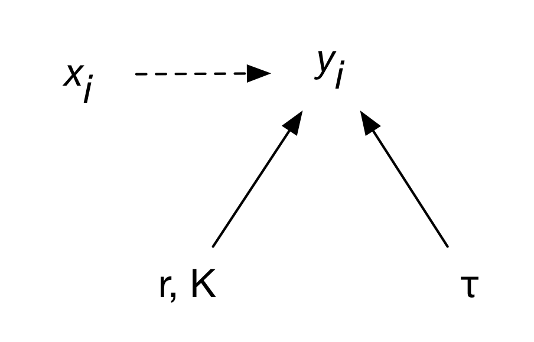

Fig 1. Bayesian network for logistic model.

Factoring the joint using the chain rule:
$$[r,K,\tau, \mathbf{y}]=[y\mid r,K,\tau][r|K,\tau][K|\tau][\tau]$$

Simplifying under the assumption of $r,K,\tau$ are indepdent:
$$[r,K,\tau, \mathbf{y}]=[y\mid r,K,\tau][r][K][\tau]$$

We would obtain the same result by inspecting the DAG and using the rules:

- All random variables on at the head of arrows must be on the lhs of a conditioning symbol.
- All random varibles at the tails of arrows must be on the rhs of a conditioning symbol.
- All random variables at the tails of arrows with no arrows coming into them must be expressed unconditionally.

#### Exercise 2: Can you improve these priors?

A recurring theme in this course will be to use priors that are informative whenever possible. The gamma priors in equation 3 include *the entire number line $>0$.* Don’t we know more about population biology than that? Lets, say for now that we are modeling the population dynamics of a large mammal. How might you go about making the priors on population parameters more informative?

**Answer:** A great source for priors in biology are allometric scaling relationships that predict all kinds of biological quantities based on the mass organisms (Peters, 1983; Pennycuick,1992). If you know the approximate mass of the animal, you can compute broad but nonetheless informative priors on $r$ and $K$. This might leave out the social scientists, but I would trust the scaling of $r$ for people if not $K$.

In the absence of some sort of scholarly way to find priors, we can at least constrain them somewhat. There is no way that a large mammal can have an intrinsic rate of increase exceeding 1 – many values for $r$ within gamma(.001, .001) are far large than than that and hence are complete nonsense. We know $r$ must be positive and we can put a plausible bound on its upper limit. The only requirement for a vague prior is that its “$\ldots$ range of uncertainty should be clearly wider that the range of reasonable values of the parameter$\ldots$” (Gelman and Hill, 2009, page 355), so we could use $r$ ~ uniform(0, 2) and be sure that it would be minimally informative. Similarly, we could use experience and knowledge to put some reasonable bounds on $K$ and even $\sigma$, which we can use to calculate $\tau$ as $\tau=\frac{1}{\sigma^{2}}$.

Peters. *The ecological implications of body size*. Cambridge University Press, Cambridge, United Kingdom, 1983.

C. J. Pennycuick. *Newton rules biology*. Oxford University Press, Oxford United Kingdom, 1992.

A. Gelman and J. Hill. *Data analysis using regression and multilievel / hierarchical modeling*. Cambridge University Press, Cambridge, United Kingdom, 2009.

#### Exercise 3: Using `for loops`

Write a code fragment to set vague normal priors for 5 regression coefficients – `dnorm(0, 10E-6)` – stored in the vector **b**.

```r
for(i in 1:5){
  b[i] ~ dnorm(0, .000001)
}
```

#### Exercise 4: Coding the logistic regression

Write R code (algorithm 3) to run the JAGS model (algorithm 2) and estimate the parameters, $r$, $K$ $\sigma$, and $\tau$. We suggest you insert the JAGS model into this R script using the `sink` command as shown in algorithm 4. You will find this a very convenient way to keep all your code in the same R script.

We use the `sink` command to create a JAGS script from our joint distribution. This file is created within R and saved in the working directory. Please note that the outer set of brackets are only required when running this code within an R markdown document (as we did to make this answer key). If you are running them in a plain R script, they are not needed.

```r
{ # Extra bracket needed only for R markdown files
sink("LogisticJAGS.R")
cat("
model{
  # priors
  K ~ dunif(0, 4000)
  r ~ dunif (0, 2)
  sigma ~ dunif(0, 50)
  tau <- 1/sigma^2

  # likelihood
  for(i in 1:n){
    mu[i] <- r - r/K * x[i]
    y[i] ~ dnorm(mu[i], tau)
  }
}
",fill = TRUE)
sink()
} # Extra bracket needed only for R markdown files
```

Then we run the remaining commands discussed in the JAGS Primer. Note that `jm` is calling the JAGS script `LogisticJAGS.R` we just created.

```r
rm(list = ls())

library(ESS575)
library(rjags)
```

```r
set.seed(1)
#Be sure to do this sorting.  It will be important for plotting later.
Logistic <- Logistic[order(Logistic$PopulationSize),]

inits = list(
  list(K = 1500, r = .2, sigma = .01),
  list(K = 1000, r = .15, sigma = .5),
  list(K = 900, r = .3, sigma = .01))

data = list(
  n = nrow(Logistic),
  x = as.double(Logistic$PopulationSize),
  y = as.double(Logistic$GrowthRate))

n.adapt = 1000
n.update = 10000
n.iter = 10000

jm = jags.model("LogisticJAGS.R", data = data, inits = inits, n.chains = length(inits), n.adapt = n.adapt)
update(jm, n.iter = n.update)
zm = coda.samples(jm, variable.names = c("K", "r", "sigma", "tau"), n.iter = n.iter, n.thin = 1)
summary(zm)
```

```
##
## Iterations = 11001:21000
## Thinning interval = 1
## Number of chains = 3
## Sample size per chain = 10000
##
## 1. Empirical mean and standard deviation for each variable,
##    plus standard error of the mean:
##
##            Mean        SD  Naive SE Time-series SE
## K     1.238e+03 6.460e+01 3.730e-01      8.013e-01
## r     2.007e-01 9.854e-03 5.689e-05      1.199e-04
## sigma 2.865e-02 3.033e-03 1.751e-05      2.506e-05
## tau   1.259e+03 2.609e+02 1.506e+00      2.075e+00
##
## 2. Quantiles for each variable:
##
##            2.5%       25%       50%       75%     97.5%
## K     1.129e+03 1.193e+03 1.232e+03 1.276e+03 1.381e+03
## r     1.809e-01 1.942e-01 2.007e-01 2.072e-01 2.199e-01
## sigma 2.344e-02 2.648e-02 2.837e-02 3.052e-02 3.529e-02
## tau   8.030e+02 1.074e+03 1.242e+03 1.426e+03 1.821e+03
```

```r
gelman.diag(zm)
```

```
## Potential scale reduction factors:
##
##       Point est. Upper C.I.
## K              1          1
## r              1          1
## sigma          1          1
## tau            1          1
##
## Multivariate psrf
##
## 1
```

#### Exercise 5: Coding the logistic regression to run in parallel (optional)

Append R code (algorithm 5) to the script you made in exercise 4 to run the JAGS model (algorithm 2) in parallel and estimate the parameters, $r$, $K$ $\sigma$, and $\tau$. Use the `proc.time` function in R to compare the time required for the sequential and parallel JAGS run. If your computer has 3 cores, try running only 2 chains in parallel when doing this exercise. If you have fewer than 3 cores, work with a classmate that has at least 3 cores.

Now we run the model in parallel using the code from algorithm 5. We use the `proc.time` function to see how long JAGS takes to run the Logistics model in parallel.

```r
# run JAGS model in parallel
library(rjags)
library(dclone)
```

```
## dclone 2.2-0      2018-02-26
```

```r
library(doParallel)
run_parallel <- function(){
  out <- clusterEvalQ(cl, {
  library(rjags)
   jm = jags.model(model_file, data = data, inits = initFunc(),
                  n.chains = 1, n.adapt = n.adapt)
  update(jm, n.iter = n.update)
  zmCore = coda.samples(jm, variable.names = variables, n.iter = n.iter, thin = 1)
  return(as.mcmc(zmCore))
  stopCluster(cl)
})

} # end of run parallel function

#Code for calling model.  Returns a coda object.

#Specify number of threads to use, i.e., the number of parallel chains.


#num_cores <- round(detectCores() * .60)  # If you have a 2 core machine, there are 4 threads, which is what is reported by detectCores(). You probably want to use no more than 3 out of 4 threads on a two core machine.  I have an 8 thread machine and I ususally run 4 or 5 cores. Running too many threads will bring other applications to a crawl.

#In this case, we will set the cores to 3
num_cores = 3


library(ESS575)
n.adpat <- 1000
n.update <-  10000
n.iter <- 10000
model_file="LogisticJAGS.R"
data = list(
  n = nrow(Logistic),
  x = as.double(Logistic$PopulationSize),
  y = as.double(Logistic$GrowthRate))
initFunc <- function (){
  return(list(
    K = runif(1, 10, 4000),
    r = runif(1, .01, 2),
    sigma = runif(1, 0, 2)
    ))
  }
initFunc()
```

```
## $K
## [1] 1069.38
##
## $r
## [1] 0.7505266
##
## $sigma
## [1] 1.145707
```

```r
variables=c("r","K", "sigma")
#The next two statements set up the clusters giving each the information it needs .  They must have global scope, i.e., they cannot be put inside the fucntion
cl <- makeCluster(num_cores) #
clusterExport(cl, c("model_file", "data", "initFunc", "n.adapt", "n.update", "n.iter", "variables"))
# Run the model and get output
ptm=proc.time()
out=run_parallel()
zcP = as.mcmc.list(out) #for coda output must have as.mcmc.list
ParallelTime <- proc.time() - ptm
ParallelTime
```

```
##    user  system elapsed
##   0.006   0.001   1.085
```

```r
summary(zcP)
```

```
##
## Iterations = 11001:21000
## Thinning interval = 1
## Number of chains = 3
## Sample size per chain = 10000
##
## 1. Empirical mean and standard deviation for each variable,
##    plus standard error of the mean:
##
##            Mean        SD  Naive SE Time-series SE
## K     1.238e+03 63.126596 3.645e-01      0.7605044
## r     2.007e-01  0.009657 5.575e-05      0.0001138
## sigma 2.867e-02  0.003032 1.751e-05      0.0000241
##
## 2. Quantiles for each variable:
##
##            2.5%       25%       50%       75%     97.5%
## K     1.129e+03 1.195e+03 1.234e+03 1.276e+03 1.376e+03
## r     1.816e-01 1.942e-01 2.008e-01 2.071e-01 2.198e-01
## sigma 2.348e-02 2.655e-02 2.839e-02 3.054e-02 3.531e-02
```

```r
gelman.diag(zcP)
```

```
## Potential scale reduction factors:
##
##       Point est. Upper C.I.
## K              1          1
## r              1          1
## sigma          1          1
##
## Multivariate psrf
##
## 1
```

We rerun the model sequentially and use `proc.time` again for comparison.

```r
ptm <- proc.time()
jm = jags.model("LogisticJAGS.R", data = data, inits = inits, n.chains = length(inits), n.adapt = n.adapt)
update(jm, n.iter = n.update)
zm = coda.samples(jm, variable.names = c("K", "r", "sigma"), n.iter = n.iter, n.thin = 1)
SequentialTime <- proc.time() - ptm
SequentialTime
```

```
##    user  system elapsed
##   3.284   0.029   3.470
```

Looks as if the parallel model runs 3.2 times faster. This factor should increase the more iterations you run (why?).

#### Exercise 6: Understanding coda ojects

```r
#Make a data frame
df = as.data.frame(rbind(zm[[1]], zm[[2]], zm[[3]]))
#Look at the first six rows:
head(df)
```

```
##          K         r      sigma
## 1 1298.627 0.1898903 0.02700248
## 2 1303.717 0.1975579 0.03365988
## 3 1307.421 0.1921679 0.02602146
## 4 1235.595 0.1936347 0.02828177
## 5 1230.479 0.1984179 0.02535492
## 6 1252.485 0.1999921 0.02526909
```

```r
# Find the mean of r for the first 1000 iterations
mean(df$r[1: 1000])
```

```
## [1] 0.2023833
```

```r
# Find the mean of r for the last 1000 iterations
nr = length(df$r)
mean(df$r[(nr - 1000): nr])
```

```
## [1] 0.2006203
```

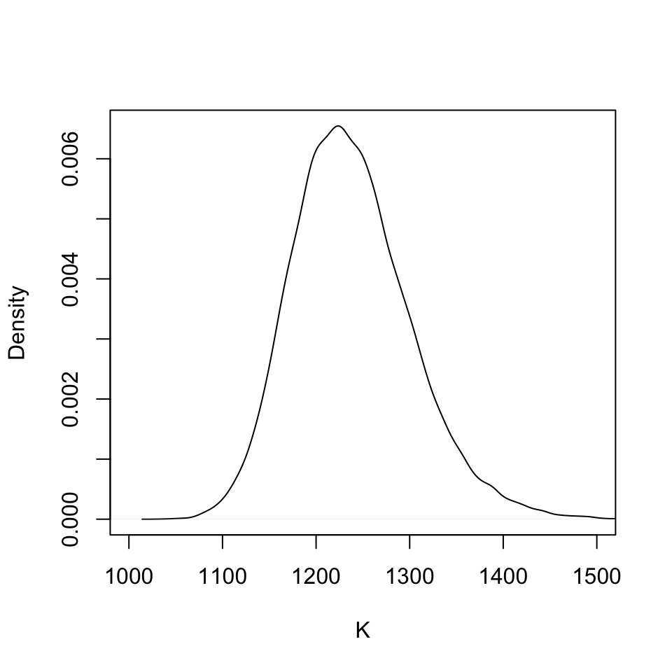

Fig. 2. Posterior density of K.

```r
#Make a publication quality plot of the marginal posterior distribution of K as a smooth curve.  (More iterations would produce a smoother cruve) and as a histogram.
plot(density(df$K), main = "", xlim=c(1000, 1500), xlab = "K")
```

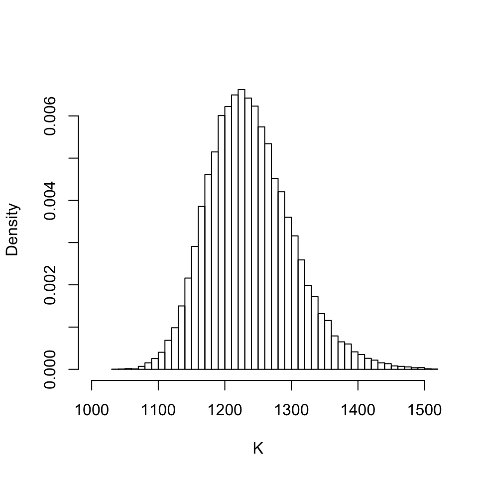

Fig. 2. Posterior density of K.

```r
hist(df$K, main = "", xlim=c(1000, 1500), xlab = "K", breaks = 50, freq=FALSE)
```

```r
# Find the probability that the parameter K exceeds 1600
1 - ecdf(df$K)(1600)
```

```
## [1] 0
```

```r
# Find the probability that the parameter 1000 < K < 1300
ecdf(df$K)(1300) - ecdf(df$K)(1000)
```

```
## [1] 0.8417333
```

```r
# Compute the .025 and .975 quantiles of K
quantile(df$K,c(.025,.975))
```

```
##     2.5%    97.5%
## 1129.244 1379.582
```

#### Exercise 7: Summarizing coda objects

```r
#Summarize with four significant digits and both covergence dianostics.
library(MCMCvis)
MCMCsummary(zm, round = 4, n.eff=TRUE)
```

```
##            mean      sd      2.5%       50%     97.5% Rhat n.eff
## K     1238.2322 63.3153 1129.2445 1233.0027 1379.5823    1  7153
## r        0.2007  0.0097    0.1817    0.2006    0.2199    1  7516
## sigma    0.0287  0.0030    0.0235    0.0284    0.0353    1 15685
```

```r
#Summarize with for r alone
MCMCsummary(zm, params = "r", round = 4, n.eff=TRUE)
```

```
##     mean     sd   2.5%    50%  97.5% Rhat n.eff
## r 0.2007 0.0097 0.1817 0.2006 0.2199    1  7516
```

```r
r.ex = MCMCchains(zm, params="r")
dim(r.ex)
```

```
## [1] 30000     1
```

```r
head(r.ex)
```

```
##              r
## [1,] 0.1898903
## [2,] 0.1975579
## [3,] 0.1921679
## [4,] 0.1936347
## [5,] 0.1984179
## [6,] 0.1999921
```

```r
mean(r.ex)
```

```
## [1] 0.2006921
```

```r
ecdf(r.ex)(.18)
```

```
## [1] 0.0163
```

```r
quantile(r.ex,c(.025,.975))
```

```
##      2.5%     97.5%
## 0.1817005 0.2199347
```

#### Exercise 8: Convert the `zm` object to a data frame

1. Extract the chains for `r` and `sigma` as a data frame using `MCMCchains` and compute their .025 and .975 quantiles from the extracted object. Display three significant digits.
2. Make a publication quality histogram for the chain for `sigma`. Indicate the .025 and .975 Bayesian equal-tailed credible interval value with vertical red lines.
3. Overlay the .95 highest posterior density interval with vertical lines in blue. This is a “learn on your own” problem intended to allow you to rehearse the most important goal of this class: being sufficiently confident to figure things out. Load the package `HDinterval`, enter `HDInterval` at the console and follow your nose. Also see Hobbs and Hooten Figure 8.2.1.

```r
#Extract the chains for \textt{r} and \text(sigma} and compute their .025 and .975 quantiles from the extracted object.

ex = as.data.frame(MCMCchains(zm, params = c("r", "sigma")))
class(ex)
```

```
## [1] "data.frame"
```

```r
dim(ex)
```

```
## [1] 30000     2
```

```r
signif(apply(ex,2,quantile,c(.025, .975)),3)
```

```
##           r  sigma
## 2.5%  0.182 0.0235
## 97.5% 0.220 0.0353
```

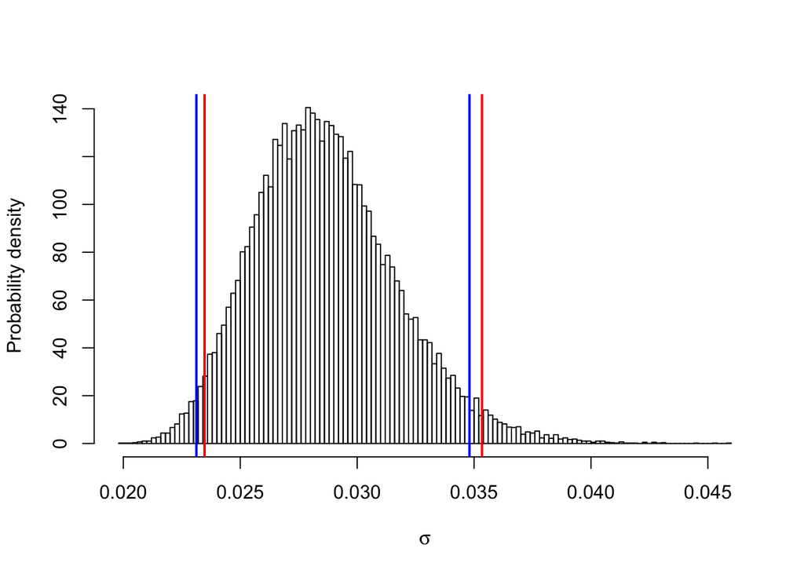

```r
#Make a publication quality historgram for the chain for sigma
hist(ex$sigma,xlab = expression(sigma), ylab = "Probability density", freq=FALSE, breaks = 100, main="")
abline(v=quantile(ex$sigma,c(.025, .975)), col = "red", lwd=2)
library(HDInterval) #load this package if needed
abline(v=hdi(ex$sigma, .95), lwd = 2, col="blue")
```

##### Exercise 9: Plotting data and model predictions using the MCMCpstr formatting

For the logistic model:

1. Plot the observations of growth rate as a function of observed population size.
2. Overlay the median of the model predictions as a solid line.
3. Overlay the 95% equal-tailed credible intervals as dashed lines in red.
4. Overlay the 95% highest posterior density intervals as dashed lines in blue.
5. What do you note about these two intervals? Will this always be the case? Why or why not?
6. What do the dashed lines represent? What inferential statement can we make about relative these lines?

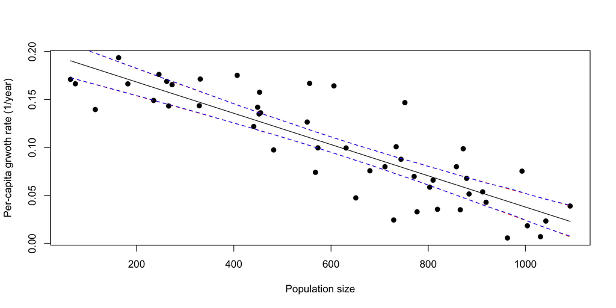

```r
library(HDInterval)
#Obtain a coda obejct including the mu parameter if you have not already done so.
zm = coda.samples(jm, variable.names = c("K", "r", "sigma", "mu"),  n.iter = 10000)

BCI <- MCMCpstr(zm, params="mu", func = function(x) quantile(x, c(.025,.5, .975)))

HPDI <-  MCMCpstr(zm, params=c("mu"), func = function(x) hdi(x,.95))
plot(data$x,data$y, pch=19, , xlab="Population size", ylab = "Per-capita grwoth rate (1/year)" )
lines(data$x,BCI$mu[,2], typ="l")
lines(data$x, BCI$mu[,1], lty="dashed", col="red")
lines(data$x, BCI$mu[,3], lty="dashed", col="red")
lines(data$x, HPDI$mu[,1], lty="dashed", col = "blue")
lines(data$x, HPDI$mu[,2], lty="dashed", col = "blue")
```

The intervals are exactly overlapping in this particular case. Such overlap will not always occur. Equal-tailed intervals based on quantiles will be broader than highest posterior density intervals when marginal posterior distributions are asymmetric.

There is a 95% probability that the true value of the mean per-capita population growth rate falls between these lines. Not that this differs from the prediction of a new observation of population growth rate, which would have much broader credible intervals.

#### Exercise 10: Creating caterpillar plots with MCMCplot

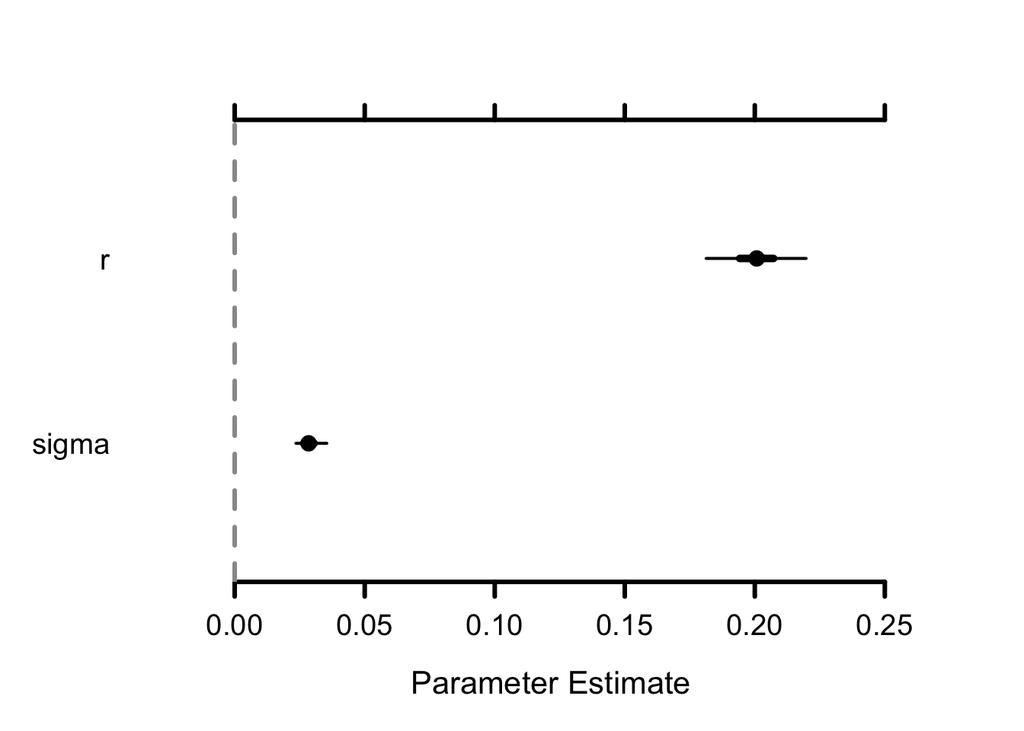

```r
MCMCplot(zm, params=c("r", "sigma"))
```

#### Exercise 11: Assessing convergence

Rerun the logistic model with `n.adapt = 100`. Then do the following:

1. Keep the next 500 iterations. Assess convergence visually with `traceplot` and with the Gelman-Rubin, Heidelberger and Welch, and Raftery diagnostics.
2. Update another 500 iterations and then keep 500 more iterations. Repeat your assessment of convergence.
3. Repeat steps 1 and 2 until you feel you have reached convergence.
4. Change the adapt phase to zero and repeat steps 1 – 4. What happens?

```r
set.seed(1)
n.adapt = 100
jm.short = jags.model("LogisticJAGS.R", data = data, inits = inits, n.chains = length(inits), n.adapt = n.adapt)
n.iter = 500
zm.short = coda.samples(jm.short, variable.names = c("K", "r", "sigma", "tau"), n.iter = n.iter, n.thin = 1)
MCMCtrace(zm.short)
gelman.diag(zm.short)
```

```
## Potential scale reduction factors:
##
##       Point est. Upper C.I.
## K           1.03       1.06
## r           1.01       1.03
## sigma       1.01       1.02
## tau         1.01       1.02
##
## Multivariate psrf
##
## 1.02
```

```r
heidel.diag(zm.short)
```

```
## [[1]]
##
##       Stationarity start     p-value
##       test         iteration
## K     passed       1         0.978
## r     passed       1         0.643
## sigma passed       1         0.661
## tau   passed       1         0.671
##
##       Halfwidth Mean     Halfwidth
##       test
## K     passed    1.24e+03 1.54e+01
## r     passed    2.00e-01 1.78e-03
## sigma passed    2.88e-02 3.82e-04
## tau   passed    1.25e+03 2.93e+01
##
## [[2]]
##
##       Stationarity start     p-value
##       test         iteration
## K     passed       1         0.659
## r     passed       1         0.807
## sigma passed       1         0.392
## tau   passed       1         0.493
##
##       Halfwidth Mean     Halfwidth
##       test
## K     passed    1.24e+03 1.75e+01
## r     passed    2.01e-01 2.76e-03
## sigma passed    2.84e-02 2.84e-04
## tau   passed    1.27e+03 2.40e+01
##
## [[3]]
##
##       Stationarity start     p-value
##       test         iteration
## K     passed         1       0.778
## r     passed         1       0.294
## sigma passed       201       0.187
## tau   passed         1       0.124
##
##       Halfwidth Mean     Halfwidth
##       test
## K     passed    1.23e+03 1.18e+01
## r     passed    2.01e-01 1.57e-03
## sigma passed    2.84e-02 3.43e-04
## tau   passed    1.27e+03 2.43e+01
```

```r
raftery.diag(zm.short)
```

```
## [[1]]
##
## Quantile (q) = 0.025
## Accuracy (r) = +/- 0.005
## Probability (s) = 0.95
##
## You need a sample size of at least 3746 with these values of q, r and s
##
## [[2]]
##
## Quantile (q) = 0.025
## Accuracy (r) = +/- 0.005
## Probability (s) = 0.95
##
## You need a sample size of at least 3746 with these values of q, r and s
##
## [[3]]
##
## Quantile (q) = 0.025
## Accuracy (r) = +/- 0.005
## Probability (s) = 0.95
##
## You need a sample size of at least 3746 with these values of q, r and s
```

```r
n.update = 500
update(jm.short, n.iter = n.update)
n.iter = 500
zm.short = coda.samples(jm.short, variable.names = c("K", "r", "sigma", "tau"), n.iter = n.iter, n.thin = 1)
MCMCtrace(zm.short)
gelman.diag(zm.short)
```

```
## Potential scale reduction factors:
##
##       Point est. Upper C.I.
## K           1.01       1.04
## r           1.01       1.03
## sigma       1.00       1.00
## tau         1.00       1.00
##
## Multivariate psrf
##
## 1.01
```

```r
heidel.diag(zm.short)
```

```
## [[1]]
##
##       Stationarity start     p-value
##       test         iteration
## K     passed       1         0.255
## r     passed       1         0.150
## sigma passed       1         0.447
## tau   passed       1         0.524
##
##       Halfwidth Mean     Halfwidth
##       test
## K     passed    1.24e+03 1.20e+01
## r     passed    2.00e-01 1.29e-03
## sigma passed    2.87e-02 3.24e-04
## tau   passed    1.25e+03 2.67e+01
##
## [[2]]
##
##       Stationarity start     p-value
##       test         iteration
## K     passed       1         0.715
## r     passed       1         0.493
## sigma passed       1         0.280
## tau   passed       1         0.251
##
##       Halfwidth Mean     Halfwidth
##       test
## K     passed    1.24e+03 1.87e+01
## r     passed    2.00e-01 2.02e-03
## sigma passed    2.88e-02 3.89e-04
## tau   passed    1.25e+03 3.09e+01
##
## [[3]]
##
##       Stationarity start     p-value
##       test         iteration
## K     failed       NA        0.00377
## r     passed        1        0.57739
## sigma passed        1        0.12302
## tau   passed        1        0.10748
##
##       Halfwidth Mean     Halfwidth
##       test
## K     <NA>            NA       NA
## r     passed    2.01e-01  0.00122
## sigma passed    2.89e-02  0.00031
## tau   passed    1.24e+03 25.92345
```

```r
raftery.diag(zm.short)
```

```
## [[1]]
##
## Quantile (q) = 0.025
## Accuracy (r) = +/- 0.005
## Probability (s) = 0.95
##
## You need a sample size of at least 3746 with these values of q, r and s
##
## [[2]]
##
## Quantile (q) = 0.025
## Accuracy (r) = +/- 0.005
## Probability (s) = 0.95
##
## You need a sample size of at least 3746 with these values of q, r and s
##
## [[3]]
##
## Quantile (q) = 0.025
## Accuracy (r) = +/- 0.005
## Probability (s) = 0.95
##
## You need a sample size of at least 3746 with these values of q, r and s
```

```r
n.update = 10000
update(jm.short, n.iter = n.update)
n.iter = 5000
zm.short = coda.samples(jm.short, variable.names = c("K", "r", "sigma", "tau"), n.iter = n.iter, n.thin = 1)
MCMCtrace(zm.short)
gelman.diag(zm.short)
```

```
## Potential scale reduction factors:
##
##       Point est. Upper C.I.
## K              1          1
## r              1          1
## sigma          1          1
## tau            1          1
##
## Multivariate psrf
##
## 1
```

```r
heidel.diag(zm.short)
```

```
## [[1]]
##
##       Stationarity start     p-value
##       test         iteration
## K     passed       1         0.707
## r     passed       1         0.639
## sigma passed       1         0.383
## tau   passed       1         0.457
##
##       Halfwidth Mean     Halfwidth
##       test
## K     passed    1.24e+03 4.060335
## r     passed    2.01e-01 0.000570
## sigma passed    2.86e-02 0.000104
## tau   passed    1.26e+03 8.838462
##
## [[2]]
##
##       Stationarity start     p-value
##       test         iteration
## K     passed       1         0.993
## r     passed       1         0.883
## sigma passed       1         0.636
## tau   passed       1         0.503
##
##       Halfwidth Mean     Halfwidth
##       test
## K     passed    1.24e+03 4.932639
## r     passed    2.01e-01 0.000621
## sigma passed    2.86e-02 0.000110
## tau   passed    1.26e+03 9.005946
##
## [[3]]
##
##       Stationarity start     p-value
##       test         iteration
## K     passed       1         0.957
## r     passed       1         0.783
## sigma passed       1         0.612
## tau   passed       1         0.560
##
##       Halfwidth Mean     Halfwidth
##       test
## K     passed    1.24e+03 5.14e+00
## r     passed    2.01e-01 6.55e-04
## sigma passed    2.86e-02 9.88e-05
## tau   passed    1.27e+03 8.11e+00
```

```r
raftery.diag(zm.short)
```

```
## [[1]]
##
## Quantile (q) = 0.025
## Accuracy (r) = +/- 0.005
## Probability (s) = 0.95
##
##        Burn-in  Total Lower bound  Dependence
##        (M)      (N)   (Nmin)       factor (I)
##  K     7        8120  3746         2.17
##  r     7        7534  3746         2.01
##  sigma 4        4792  3746         1.28
##  tau   5        5483  3746         1.46
##
##
## [[2]]
##
## Quantile (q) = 0.025
## Accuracy (r) = +/- 0.005
## Probability (s) = 0.95
##
##        Burn-in  Total Lower bound  Dependence
##        (M)      (N)   (Nmin)       factor (I)
##  K     10       10992 3746         2.93
##  r     10       11706 3746         3.12
##  sigma 4        4636  3746         1.24
##  tau   7        7263  3746         1.94
##
##
## [[3]]
##
## Quantile (q) = 0.025
## Accuracy (r) = +/- 0.005
## Probability (s) = 0.95
##
##        Burn-in  Total Lower bound  Dependence
##        (M)      (N)   (Nmin)       factor (I)
##  K     9        9497  3746         2.54
##  r     6        6295  3746         1.68
##  sigma 4        4636  3746         1.24
##  tau   6        6805  3746         1.82
```